# A3: SPL Library Checkouts

### Introduction

I chose to analyze the Seattle Public Library checkouts from the years 2022 to 2023. I picked this one because it is the most up to date dataset. My main goal on this is to provide data about digital copies with a focus on the genre mystery. I choose this because ever since the pandemic, I’ve noticed a lot of people aren’t using paper copies anymore and were transitioning to technology. Myself, I only like digital books and I want to see how prevalent digital copies are. I’ve always enjoyed a good mystery book, so I decided to combine to two to research.

### Summary Information

The values I decided to produce were all filtering through books that has a tie to mystery. I expected there to be a slight difference between physical copies and digital copies but the numbers surprised me. Digital had a whooping 679811 checkouts while physical had only 89628, which makes the difference of 590183. Knowing that digital had a big consumer rate, the next value was going to be finding what kind of digital preference was most checked out. I found that EBOOK was a big contributor to the digital checkout, while AUDIOBOOK was the lowest. January was the most popular month that people were checking out digital books. Along with popularity, Agatha Christie was the top author for the genre and digital copies.

### The Dataset

- Who collected/published the data? The data was collected by the Seattle Public Library and is accessed through Seattle Open Data.
- What are the parameters of the data (dates, number of checkouts, kinds of books, etc.)? UsageClass, CheckoutType, MaterialType, CheckoutYear, CheckoutMonth, Checkouts, Title, ISBN, Creator, Subjects, Publisher, PublicationYear
- How was the data collected or generated? This data was collected every month through checkouts using titles.
- Why was the data collected? This data is collected to see trends about how/what the people of Seattle are reading.
- What, if any, ethical questions do you need to consider when working with this data? A question I would have is if the people checking out these books know that their choices in books are being shared publicly?
- What are possible limitations or problems with this data? (at least 200 words) A main limitation can be that this data is updated monthly. This will mean that someone who wanted to access the data for the recent month would have to wait until the next month to be able to see it. I also noticed that there were a lot of missing data in some sections of ISBN, Creator, Subjects, Publisher and Publication Year. Having missing data can cause problems, even in such a big dataset. The missing data can create imbalances to the observations and can lead to a wrong conclusion. Although many people check out certain books or maybe multiple at a time, it can be unsure that after checkout they will actually read them. Or if someone is taking longer to read, which would require them to check out the same book multiple times. Both of those situations can also mess with some of the data. When it comes to authors, some of the names read last name to first name or vice versa. This creates the problem when having to search through authors and their names are flopped. Also looking deeper into the Author column, I can see that some authors have dates next to their name which may indicate their death or birth year, which could be useless in the context of this dataset and makes it harder to search through.

### First Trends Over Time Chart

This chart compares how much checkouts of physical compared to digital are. I wanted to capture the decline of physical books continuing forward after the pandemic.The pattern that emerges is that books are at an all time high at the beginning of 2022 and start declining. There is a big difference in 2022 compared to 2023. But there is a big difference between digital and physical. Digital has a big drop compared to physical overtime.

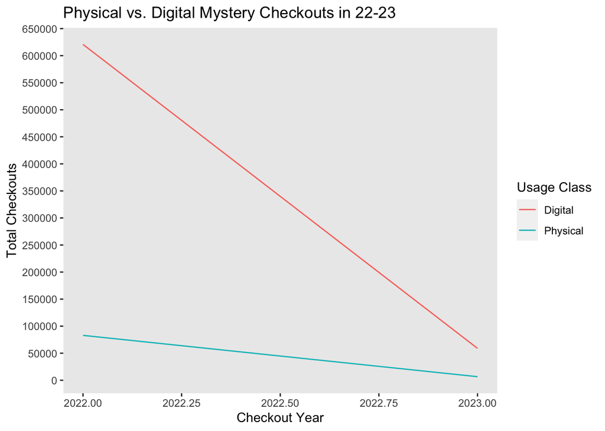

### Second Trends Over Time Chart

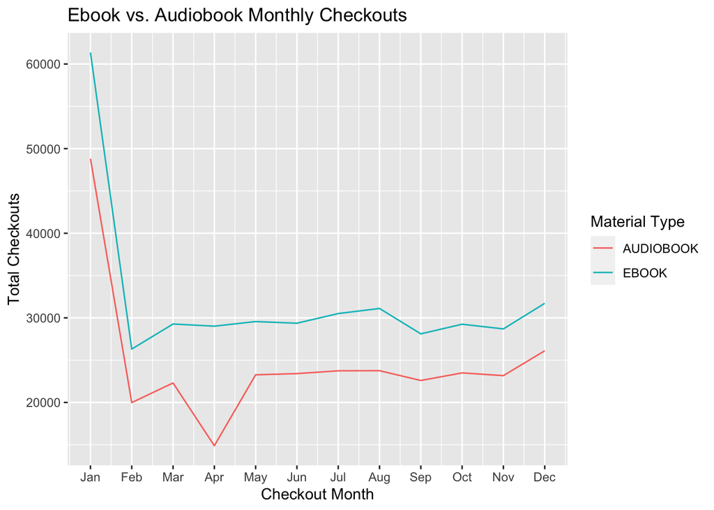

### Your Choice

After seeing the first chart about yearly, I was enticed to see what difference was for months. This chart shows 2022 and 2023 months combined. I chose a stacked bar plot because I thought it was the best way for grouping when categorizing by months and it’s able to showcase the two checkout comparisons better. This is really interesting because you can see how January was the most checked out for both and then the rest of the months it starts to straighten out. But in the end you can see the contrast of colors where digital takes over most of the chart.

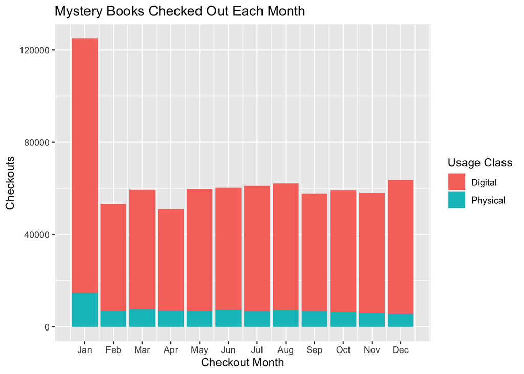